# Masters Markdown

Jilly Hebert

20 April 2021

# Simulated Data

Two simulated datasets were built to emulate nested designs. They were both built from a gamma distribution and incorporated a skewness of 0.5. Comparisons were made between estimated model powers, estimations, and confidence intervals. Nine unique cases were assessed to compare differences when data structures differ.

## No Treatment Effect

This simulated dataset had no treatment effect, so powers should be close to 0.05. The table below shows that the fixed model has a significantly higher power than the other three models, and an unexpectedly high power for a dataset with no treatment effect.

| Case | Alpha | Between Subject SD | Within Subject SD | Number of Subjects | Number of Repetitions | Pooled Power | Fixed Power | ML Power | REML Power |
| --- | --- | --- | --- | --- | --- | --- | --- | --- | --- |
| 1 | 0.05 | 2 | 5 | 10 | 10 | 0.053 | 0.758 | 0.061 | 0.053 |
| 2 | 0.05 | 5 | 2 | 10 | 10 | 0.037 | 0.909 | 0.046 | 0.037 |
| 3 | 0.05 | 3 | 3 | 10 | 10 | 0.050 | 0.839 | 0.060 | 0.050 |
| 4 | 0.05 | 2 | 5 | 5 | 20 | 0.049 | 0.843 | 0.063 | 0.049 |
| 5 | 0.05 | 5 | 2 | 5 | 20 | 0.052 | 0.917 | 0.075 | 0.052 |
| 6 | 0.05 | 3 | 3 | 5 | 20 | 0.044 | 0.904 | 0.066 | 0.044 |
| 7 | 0.05 | 2 | 5 | 20 | 5 | 0.049 | 0.660 | 0.053 | 0.049 |
| 8 | 0.05 | 5 | 2 | 20 | 5 | 0.056 | 0.858 | 0.063 | 0.056 |
| 9 | 0.05 | 3 | 3 | 20 | 5 | 0.046 | 0.754 | 0.050 | 0.046 |

When comparing the 95% confidence intervals, the fixed model had the tightest intervals and failed to capture uncertainty.

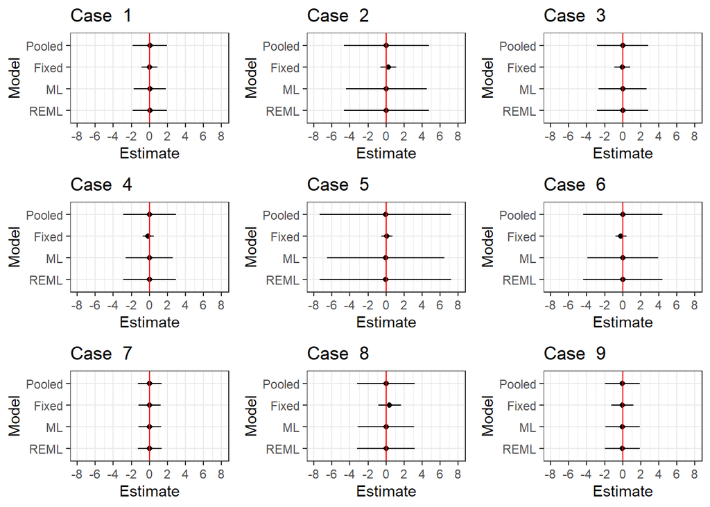

## Treatment Effect

This simulated dataset had a treatment effect of 3, or half of the standard deviation of the gamma distribution. Higher powers indicate better fits.

| Case | Alpha | Between Subject SD | Within Subject SD | Number of Subjects | Number of Repetitions | Pooled Power | Fixed Power | ML Power | REML Power |
| --- | --- | --- | --- | --- | --- | --- | --- | --- | --- |
| 1 | 0.05 | 2 | 5 | 10 | 10 | 0.890 | 0.878 | 0.909 | 0.890 |
| 2 | 0.05 | 5 | 2 | 10 | 10 | 0.239 | 0.908 | 0.266 | 0.239 |
| 3 | 0.05 | 3 | 3 | 10 | 10 | 0.512 | 0.863 | 0.549 | 0.512 |
| 4 | 0.05 | 2 | 5 | 5 | 20 | 0.447 | 0.898 | 0.545 | 0.447 |
| 5 | 0.05 | 5 | 2 | 5 | 20 | 0.120 | 0.942 | 0.160 | 0.120 |
| 6 | 0.05 | 3 | 3 | 5 | 20 | 0.219 | 0.904 | 0.286 | 0.219 |
| 7 | 0.05 | 2 | 5 | 20 | 5 | 0.995 | 0.825 | 0.995 | 0.995 |
| 8 | 0.05 | 5 | 2 | 20 | 5 | 0.430 | 0.854 | 0.451 | 0.430 |
| 9 | 0.05 | 3 | 3 | 20 | 5 | 0.870 | 0.833 | 0.877 | 0.870 |

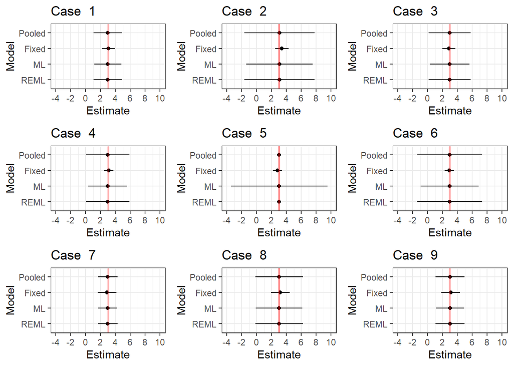

## Confidence Interval Comparisons

When making comparisons between intervals, it was found that the pooled and restricted maximum likelihood models had identical results. It was also found that regardless of treatment effects, the intervals were around the same average width.

| Case | Model | No Treatment Effect Interval Width | Treatment Effect Interval Width |
| --- | --- | --- | --- |
| 1 | Pooled | 3.7960 | 3.8062 |
| 1 | Fixed | 1.7649 | 1.7661 |
| 1 | ML | 3.6012 | 3.6109 |
| 1 | REML | 3.7960 | 3.8062 |
| 2 | Pooled | 9.4194 | 9.4010 |
| 2 | Fixed | 1.7650 | 1.7647 |
| 2 | ML | 8.9361 | 8.9186 |
| 2 | REML | 9.4194 | 9.4010 |
| 3 | Pooled | 5.6584 | 5.6579 |
| 3 | Fixed | 1.7656 | 1.7655 |
| 3 | ML | 5.3680 | 5.3675 |
| 3 | REML | 5.6584 | 5.6579 |
| 4 | Pooled | 5.8498 | 5.8291 |
| 4 | Fixed | 1.2481 | 1.2466 |
| 4 | ML | 5.2322 | 5.2137 |
| 4 | REML | 5.8498 | 5.8291 |
| 5 | Pooled | 14.5472 | 14.5080 |
| 5 | Fixed | 1.2472 | 1.2476 |
| 5 | ML | 13.0114 | 12.9764 |
| 5 | REML | 14.5472 | 14.5080 |
| 6 | Pooled | 8.7538 | 8.7162 |
| 6 | Fixed | 1.2469 | 1.2482 |
| 6 | ML | 7.8296 | 7.7960 |
| 6 | REML | 8.7538 | 8.7162 |
| 7 | Pooled | 2.6208 | 2.6209 |
| 7 | Fixed | 2.4958 | 2.4965 |
| 7 | ML | 2.5545 | 2.5546 |
| 7 | REML | 2.6208 | 2.6209 |
| 8 | Pooled | 6.4161 | 6.4332 |
| 8 | Fixed | 2.5000 | 2.5000 |
| 8 | ML | 6.2536 | 6.2703 |
| 8 | REML | 6.4161 | 6.4332 |
| 9 | Pooled | 3.8821 | 3.8798 |
| 9 | Fixed | 2.4960 | 2.4944 |
| 9 | ML | 3.7838 | 3.7815 |
| 9 | REML | 3.8821 | 3.8798 |

| Model | Average No Effect Width | Average Effect Width |
| --- | --- | --- |
| Pooled | 6.7715 | 6.7614 |
| Fixed | 1.8366 | 1.8366 |
| ML | 6.2856 | 6.2766 |
| REML | 6.7715 | 6.7614 |

| Case | No Effect ML Width | No Effect REML Width | Effect ML Width | Effect REML Width | No Effect Percent | Effect Percent |
| --- | --- | --- | --- | --- | --- | --- |
| 1 | 3.6012 | 3.7960 | 3.6109 | 3.8062 | 2.9838 | 2.9962 |
| 2 | 8.9361 | 9.4194 | 8.9186 | 9.4010 | 7.4040 | 7.4003 |
| 3 | 5.3680 | 5.6584 | 5.3675 | 5.6579 | 4.4477 | 4.4538 |
| 4 | 5.2322 | 5.8498 | 5.2137 | 5.8291 | 9.4597 | 9.4400 |
| 5 | 13.0114 | 14.5472 | 12.9764 | 14.5080 | 23.5242 | 23.4952 |
| 6 | 7.8296 | 8.7538 | 7.7960 | 8.7162 | 14.1557 | 14.1156 |
| 7 | 2.5545 | 2.6208 | 2.5546 | 2.6209 | 1.0165 | 1.0180 |
| 8 | 6.2536 | 6.4161 | 6.2703 | 6.4332 | 2.4884 | 2.4987 |
| 9 | 3.7838 | 3.8821 | 3.7815 | 3.8798 | 1.5056 | 1.5069 |

# Exposure Related Effects of Zequanox

This empirical dataset was obtained from U.S. Geological Survey. This study evaluated the impacts of the chemical Zequanox, which is used to control invasive mussels, on the native fish species lake trout and lake sturgeon.

## Exploratory Graphics

Graphics show that on average, lake trout had a higher condition factor, and the treatment levels had more variation in comparison to lake sturgeon.

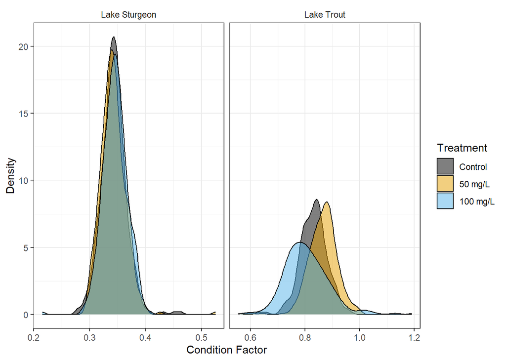

| Tank | Species | Minimum Weight | Average Weight | Maximum Weight | Minimum Length | Average Lenght | Maximum Length | Minimum Condition Factor | Average Conition Factor | Maximum Condition Factor | Count |
| --- | --- | --- | --- | --- | --- | --- | --- | --- | --- | --- | --- |
| 1 | Lake Trout | 3.20 | 6.2872 | 10.16 | 75 | 91.5000 | 104 | 0.670 | 0.8022 | 0.944 | 50 |
| 1 | Lake Sturgeon | 14.07 | 21.7716 | 32.00 | 145 | 184.0800 | 209 | 0.278 | 0.3462 | 0.463 | 100 |
| 2 | Lake Trout | 5.94 | 9.8469 | 19.05 | 94 | 105.0400 | 128 | 0.715 | 0.8366 | 0.969 | 100 |
| 2 | Lake Sturgeon | 11.02 | 20.3645 | 32.20 | 151 | 180.8300 | 201 | 0.293 | 0.3411 | 0.399 | 100 |
| 3 | Lake Trout | 3.93 | 6.0560 | 9.80 | 82 | 90.2400 | 104 | 0.687 | 0.8142 | 1.130 | 50 |
| 3 | Lake Sturgeon | 12.74 | 20.8258 | 29.55 | 152 | 183.0800 | 206 | 0.303 | 0.3372 | 0.388 | 100 |
| 4 | Lake Trout | 5.49 | 8.8747 | 14.09 | 87 | 100.5000 | 113 | 0.764 | 0.8629 | 1.000 | 100 |
| 4 | Lake Sturgeon | 5.49 | 19.5513 | 30.32 | 117 | 176.9000 | 211 | 0.301 | 0.3468 | 0.392 | 100 |
| 5 | Lake Trout | 5.26 | 9.0260 | 13.47 | 87 | 103.0600 | 117 | 0.631 | 0.8141 | 0.954 | 100 |
| 5 | Lake Sturgeon | 12.06 | 20.7352 | 34.04 | 152 | 181.4900 | 209 | 0.301 | 0.3435 | 0.399 | 100 |
| 6 | Lake Trout | 3.27 | 6.0415 | 9.93 | 75 | 90.5185 | 104 | 0.583 | 0.7983 | 1.030 | 54 |
| 6 | Lake Sturgeon | 13.05 | 21.7574 | 36.93 | 158 | 184.4100 | 223 | 0.292 | 0.3436 | 0.432 | 100 |
| 7 | Lake Trout | 3.97 | 9.2675 | 15.13 | 82 | 102.4200 | 119 | 0.569 | 0.8499 | 1.190 | 100 |
| 7 | Lake Sturgeon | 9.97 | 20.7803 | 30.07 | 140 | 180.6211 | 205 | 0.215 | 0.3484 | 0.408 | 95 |
| 8 | Lake Trout | 5.81 | 8.8383 | 14.15 | 88 | 100.1212 | 116 | 0.766 | 0.8694 | 0.990 | 99 |
| 8 | Lake Sturgeon | 7.49 | 20.5356 | 30.60 | 129 | 180.3061 | 202 | 0.299 | 0.3465 | 0.388 | 98 |
| 9 | Lake Trout | 4.48 | 9.1132 | 16.18 | 85 | 103.4343 | 123 | 0.555 | 0.8098 | 0.923 | 99 |
| 9 | Lake Sturgeon | 11.02 | 20.3974 | 31.28 | 128 | 180.1500 | 208 | 0.301 | 0.3463 | 0.525 | 100 |
| 10 | Lake Trout | 6.08 | 10.2105 | 18.96 | 90 | 105.2600 | 129 | 0.782 | 0.8589 | 0.957 | 100 |
| 10 | Lake Sturgeon | 13.37 | 21.6723 | 32.56 | 151 | 184.3900 | 212 | 0.279 | 0.3427 | 0.391 | 100 |
| 11 | Lake Trout | 4.88 | 8.5393 | 13.35 | 84 | 98.3838 | 113 | 0.756 | 0.8821 | 0.996 | 99 |
| 11 | Lake Sturgeon | 8.19 | 19.8497 | 30.66 | 135 | 179.3500 | 205 | 0.292 | 0.3394 | 0.384 | 100 |
| 12 | Lake Trout | 3.30 | 6.3403 | 10.32 | 75 | 91.8644 | 107 | 0.610 | 0.8036 | 1.050 | 59 |
| 12 | Lake Sturgeon | 11.39 | 20.8653 | 30.60 | 150 | 182.8500 | 207 | 0.290 | 0.3389 | 0.451 | 100 |

## Pooled Model

The pooled model fit a linear model with treatment level and species as fixed predictors. The pooled condition factor was used as the response.

|  | Estimate | Std. Error | Lower 95% CI | Upper 95% CI | t-Value | p-Value |
| --- | --- | --- | --- | --- | --- | --- |
| (Intercept) | 0.8314 | 0.0074 | 0.8160 | 0.8468 | 112.4413 | <0.0001 |
| Treatment50 mg/L | 0.0177 | 0.0091 | -0.0012 | 0.0366 | 1.9552 | 0.0647 |
| Treatment100 mg/L | -0.0114 | 0.0091 | -0.0303 | 0.0075 | -1.2596 | 0.2223 |
| SpeciesLST | -0.4901 | 0.0074 | -0.5055 | -0.4747 | -66.2862 | <0.0001 |

## Fixed Model

The fixed model fit a linear model with treatment level, species, and tank as fixed predictors. It used the original condition factor as the response.

|  | Estimate | Std. Error | Lower 95% CI | Upper 95% CI | t-Value | p-Value |
| --- | --- | --- | --- | --- | --- | --- |
| (Intercept) | 0.8098 | 0.0043 | 0.8014 | 0.8182 | 189.5437 | <0.0001 |
| Treatment50 mg/L | -0.0078 | 0.0095 | -0.0265 | 0.0109 | -0.8190 | 0.4129 |
| Treatment100 mg/L | -0.0076 | 0.0074 | -0.0221 | 0.0069 | -1.0288 | 0.3037 |
| SpeciesLST | -0.4557 | 0.0074 | -0.4702 | -0.4412 | -61.6828 | <0.0001 |

## Maximum Likelihood Model

The maximum likelihood model fit a linear mixed effects model with treatment level and species as fixed predictors. Unique fish nested in tank was used as the random predictor and the original condition factor was the response. The maximum likelihood algorithm was specified in the model.

|  | Estimate | Std. Error | Lower 95% CI | Upper 95% CI | t-Value | p-Value |
| --- | --- | --- | --- | --- | --- | --- |
| (Intercept) | 0.8315 | 0.0067 | 0.8184 | 0.8447 | 123.5276 | <0.0001 |
| Treatment50 mg/L | 0.0177 | 0.0082 | 0.0005 | 0.0349 | 2.1495 | 0.0440 |
| Treatment100 mg/L | -0.0110 | 0.0083 | -0.0283 | 0.0063 | -1.3240 | 0.2004 |
| SpeciesLST | -0.4904 | 0.0068 | -0.5045 | -0.4763 | -72.5871 | <0.0001 |

## Restricted Maximum Likelihood Model

The restricted maximum likelihood model fit a linear mixed effects model with treatment level and species as fixed predictors. Unique fish nested in tank was used as the random predictor and the original condition factor was the response. The restricted maximum likelihood algorithm was specified in the model.

|  | Estimate | Std. Error | Lower 95% CI | Upper 95% CI | t-Value | p-Value |
| --- | --- | --- | --- | --- | --- | --- |
| (Intercept) | 0.8315 | 0.0074 | 0.8171 | 0.8460 | 112.7938 | <0.0001 |
| Treatment50 mg/L | 0.0177 | 0.0090 | -0.0011 | 0.0365 | 1.9625 | 0.0638 |
| Treatment100 mg/L | -0.0111 | 0.0091 | -0.0300 | 0.0079 | -1.2179 | 0.2374 |
| SpeciesLST | -0.4904 | 0.0074 | -0.5058 | -0.4749 | -66.3148 | <0.0001 |

## Model Comparisons

When making comparisons, it was found that the fixed model had a significantly higher denominator degrees of freedom. This leads to a higher power and a more frequent determination of significance.

|  | Numerator DF | Denominator DF | F-Value | p-Value |
| --- | --- | --- | --- | --- |
| Pooled Treatment | 2 | 20 | 5.2481 | 0.0147 |
| Fixed Treatment | 2 | 2179 | 975.8404 | <0.0001 |
| ML Treatment | 2 | 20 | 9.1762 | 0.0015 |
| REML Treatment | 2 | 20 | 7.2226 | 0.0044 |

# Acoustic Telemetry Evaluation of Carbon Dioxide

This empirical dataset was obtained from U.S. Geological Survey. It assessed the movements of Bighead Carp and Grass Carp in a pond in response to carbon dioxide. This dataset included repeated measures which is an extra layer of complication that did not exist in the previous datasets.

## Exploratory Graphics

The original distance metric was centered about a reference point at the center of the pond. It can be seen that fish are moving away from the side that is releasing carbon dioxide.

#### Original Distance

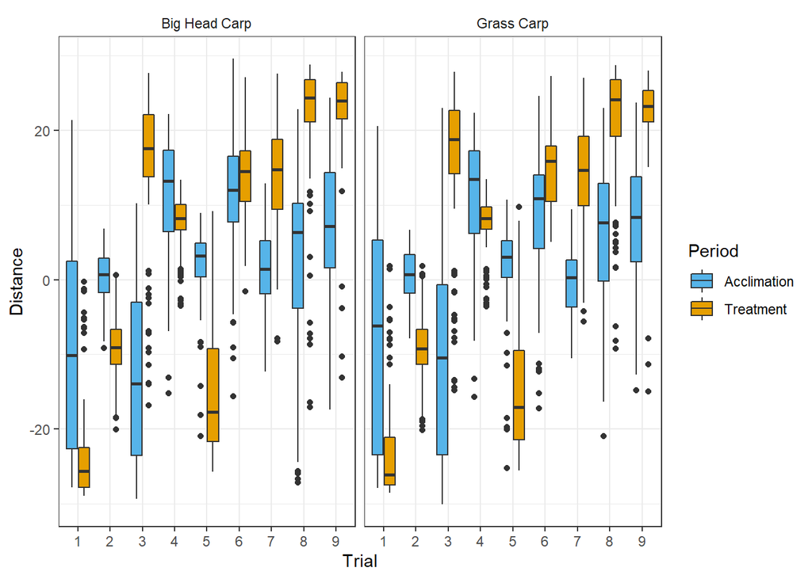

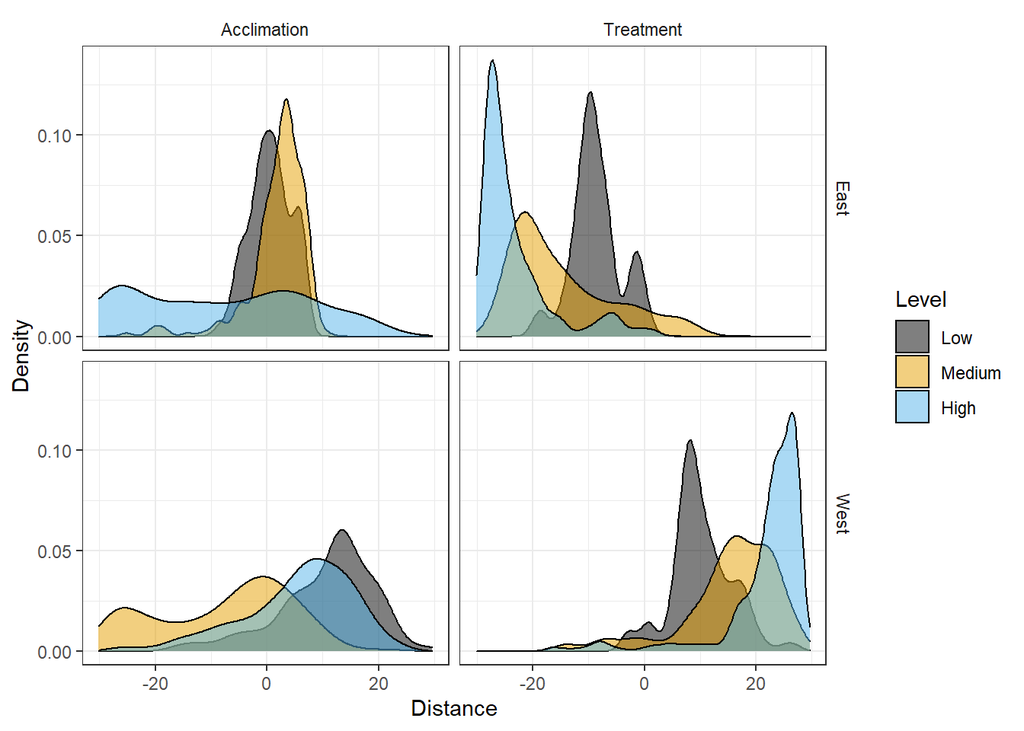

#### Absolute Distance

The absolute distance was a created using the `adehabitatLT` package. This helped create a standardized distance metric and was used as the response variable.

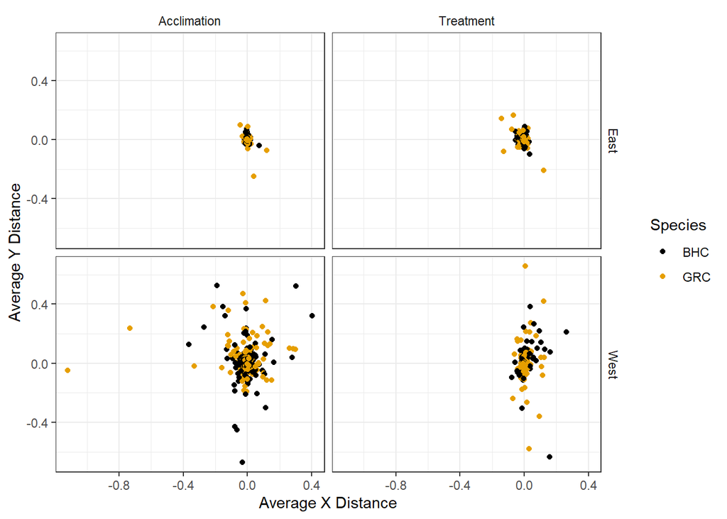

The total number of crossings during periods were also assessed. This shows that during the treatment period, the carp are moving about the pond much less since there are less frequent crossings.

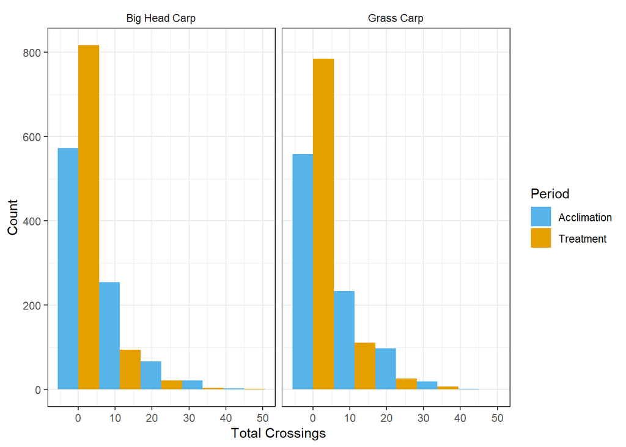

## Bighead Carp

The species were split and handled separately to maintain a nested design structure.

#### Pooled Model

The pooled model fit a linear model with period, level, and treatment side as fixed predictors. A pooled absolute distance was used as the response variable.

|  | Estimate | Std. Error | Lower 95% CI | Upper 95% CI | t-Value | p-Value |
| --- | --- | --- | --- | --- | --- | --- |
| (Intercept) | 0.2619 | 0.0545 | 0.1217 | 0.4021 | 4.8027 | 0.0049 |
| trtsideWest | 0.0757 | 0.0412 | -0.0303 | 0.1817 | 1.8356 | 0.1259 |
| levelMedium | -0.0559 | 0.0714 | -0.2395 | 0.1276 | -0.7832 | 0.4690 |
| levelHigh | 0.0303 | 0.0714 | -0.1533 | 0.2138 | 0.4237 | 0.6894 |
| periodTreatment | 0.0198 | 0.0714 | -0.1638 | 0.2033 | 0.2771 | 0.7928 |
| levelMedium:periodTreatment | 0.1005 | 0.1010 | -0.1590 | 0.3601 | 0.9956 | 0.3651 |
| levelHigh:periodTreatment | -0.1352 | 0.1010 | -0.3948 | 0.1244 | -1.3389 | 0.2383 |

#### Fixed Model

The fixed model fit a linear model with period, level, the interaction between period and level, and trial nested in level as fixed predictor variables. The original absolute distance metric was used as the response variable.

|  | Estimate | Std. Error | Lower 95% CI | Upper 95% CI | t-Value | p-Value |
| --- | --- | --- | --- | --- | --- | --- |
| (Intercept) | 0.4846 | 0.0217 | 0.4413 | 0.5279 | 22.3080 | <0.0001 |
| levelMedium | -0.1892 | 0.0306 | -0.2501 | -0.1283 | -6.1861 | <0.0001 |
| levelHigh | -0.1892 | 0.0307 | -0.2505 | -0.1280 | -6.1603 | <0.0001 |
| periodTreatment | -0.0016 | 0.0223 | -0.0460 | 0.0428 | -0.0708 | 0.9438 |
| levelMedium:periodTreatment | 0.0803 | 0.0310 | 0.0185 | 0.1420 | 2.5904 | 0.0115 |
| levelHigh:periodTreatment | -0.1308 | 0.0315 | -0.1936 | -0.0680 | -4.1495 | 0.0001 |

#### Maximum Likelihood Model

The maximum likelihood model fit a linear mixed effects model with period, level, treatment side, and the interaction between period and level as fixed predictors. Unique fish nested in trial was specified as random predictors and the original absolute distance metric was used as the response variable. The maximum likelihood method was specified in the model.

|  | Estimate | Std. Error | Lower 95% CI | Upper 95% CI | t-Value | p-Value |
| --- | --- | --- | --- | --- | --- | --- |
| (Intercept) | 0.2680 | 0.0549 | 0.1618 | 0.3743 | 4.8862 | <0.0001 |
| trtsideWest | 0.0706 | 0.0509 | -0.0549 | 0.1960 | 1.3860 | 0.2244 |
| levelMedium | -0.0416 | 0.0609 | -0.1917 | 0.1085 | -0.6831 | 0.5249 |
| levelHigh | 0.0376 | 0.0611 | -0.1129 | 0.1880 | 0.6151 | 0.5654 |
| periodTreatment | -0.0016 | 0.0228 | -0.0457 | 0.0426 | -0.0692 | 0.9452 |
| levelMedium:periodTreatment | 0.0803 | 0.0317 | 0.0189 | 0.1417 | 2.5319 | 0.0154 |
| levelHigh:periodTreatment | -0.1308 | 0.0322 | -0.1932 | -0.0683 | -4.0557 | 0.0002 |

#### Restricted Maximum Likelihood Model

The restricted maximum likelihood model fit a linear mixed effects model with period, level, treatment side, and the interaction between period and level as fixed predictors. Unique fish nested in trial was specified as random predictors and the original absolute distance metric was used as the response variable. The restricted maximum likelihood method was specified in the model.

|  | Estimate | Std. Error | Lower 95% CI | Upper 95% CI | t-Value | p-Value |
| --- | --- | --- | --- | --- | --- | --- |
| (Intercept) | 0.2678 | 0.0701 | 0.1262 | 0.4094 | 3.8221 | 0.0005 |
| trtsideWest | 0.0704 | 0.0656 | -0.0983 | 0.2391 | 1.0724 | 0.3325 |
| levelMedium | -0.0412 | 0.0774 | -0.2401 | 0.1576 | -0.5332 | 0.6168 |
| levelHigh | 0.0379 | 0.0775 | -0.1613 | 0.2371 | 0.4894 | 0.6452 |
| periodTreatment | -0.0016 | 0.0223 | -0.0466 | 0.0435 | -0.0708 | 0.9439 |
| levelMedium:periodTreatment | 0.0803 | 0.0310 | 0.0176 | 0.1429 | 2.5902 | 0.0133 |
| levelHigh:periodTreatment | -0.1308 | 0.0315 | -0.1945 | -0.0671 | -4.1491 | 0.0002 |

#### Model Comparisons

When making comparisons, it was found that the fixed model had a significantly higher denominator degrees of freedom. This leads to a higher power and a more frequent determination of significance. It’s also important to note that the pooled denominator degrees of freedom differ from the maximum likelihood and restricted maximum likelihood models. This is due to the repeated measure that exist in the dataset.

|  | Numerator DF | Denominator DF | F-Value | p-Value |
| --- | --- | --- | --- | --- |
| Pooled Level:Period | 2 | 5 | 2.7445 | 0.1569 |
| Fixed Level:Period | 2 | 74 | 23.5108 | <0.0001 |
| ML Level:Period | 2 | 40 | 22.4602 | <0.0001 |
| REML Level:Period | 2 | 40 | 23.5068 | <0.0001 |

## Grass Carp

#### Pooled Model

The pooled model fit a linear model with period, level, and treatment side as fixed predictors. A pooled absolute distance was used as the response variable.

|  | Estimate | Std. Error | Lower 95% CI | Upper 95% CI | t-Value | p-Value |
| --- | --- | --- | --- | --- | --- | --- |
| (Intercept) | 0.2648 | 0.0621 | 0.1053 | 0.4244 | 4.2668 | 0.0080 |
| trtsideWest | 0.0656 | 0.0469 | -0.0550 | 0.1862 | 1.3973 | 0.2212 |
| levelMedium | -0.0666 | 0.0813 | -0.2755 | 0.1423 | -0.8199 | 0.4496 |
| levelHigh | 0.0388 | 0.0813 | -0.1701 | 0.2477 | 0.4771 | 0.6534 |
| periodTreatment | -0.0137 | 0.0813 | -0.2226 | 0.1952 | -0.1685 | 0.8728 |
| levelMedium:periodTreatment | 0.1464 | 0.1149 | -0.1490 | 0.4418 | 1.2737 | 0.2588 |
| levelHigh:periodTreatment | -0.0949 | 0.1149 | -0.3903 | 0.2005 | -0.8256 | 0.4466 |

#### Fixed Model

The fixed model fit a linear model with period, level, the interaction between period and level, and trial nested in level as fixed predictor variables. The original absolute distance metric was used as the response variable.

|  | Estimate | Std. Error | Lower 95% CI | Upper 95% CI | t-Value | p-Value |
| --- | --- | --- | --- | --- | --- | --- |
| (Intercept) | 0.5078 | 0.0252 | 0.4575 | 0.5581 | 20.1291 | <0.0001 |
| levelMedium | -0.2309 | 0.0357 | -0.3020 | -0.1598 | -6.4718 | <0.0001 |
| levelHigh | -0.2042 | 0.0360 | -0.2760 | -0.1324 | -5.6688 | <0.0001 |
| periodTreatment | -0.0488 | 0.0252 | -0.0991 | 0.0015 | -1.9341 | 0.0569 |
| levelMedium:periodTreatment | 0.1389 | 0.0357 | 0.0678 | 0.2100 | 3.8927 | 0.0002 |
| levelHigh:periodTreatment | -0.0750 | 0.0370 | -0.1488 | -0.0013 | -2.0263 | 0.0463 |

#### Maximum Likelihood Model

The maximum likelihood model fit a linear mixed effects model with period, level, treatment side, and the interaction between period and level as fixed predictors. Unique fish nested in trial was specified as random predictors and the original absolute distance metric was used as the response variable. The maximum likelihood method was specified in the model.

|  | Estimate | Std. Error | Lower 95% CI | Upper 95% CI | t-Value | p-Value |
| --- | --- | --- | --- | --- | --- | --- |
| (Intercept) | 0.2846 | 0.0583 | 0.1717 | 0.3975 | 4.8829 | <0.0001 |
| trtsideWest | 0.0655 | 0.0540 | -0.0674 | 0.1985 | 1.2141 | 0.2789 |
| levelMedium | -0.0699 | 0.0649 | -0.2297 | 0.0899 | -1.0774 | 0.3305 |
| levelHigh | 0.0291 | 0.0653 | -0.1317 | 0.1899 | 0.4453 | 0.6747 |
| periodTreatment | -0.0488 | 0.0258 | -0.0988 | 0.0012 | -1.8915 | 0.0658 |
| levelMedium:periodTreatment | 0.1389 | 0.0365 | 0.0682 | 0.2095 | 3.8068 | 0.0005 |
| levelHigh:periodTreatment | -0.0750 | 0.0379 | -0.1484 | -0.0017 | -1.9816 | 0.0544 |

#### Restricted Maximum Likelihood Model

The restricted maximum likelihood model fit a linear mixed effects model with period, level, treatment side, and the interaction between period and level as fixed predictors. Unique fish nested in trial was specified as random predictors and the original absolute distance metric was used as the response variable. The restricted maximum likelihood method was specified in the model.

|  | Estimate | Std. Error | Lower 95% CI | Upper 95% CI | t-Value | p-Value |
| --- | --- | --- | --- | --- | --- | --- |
| (Intercept) | 0.2846 | 0.0741 | 0.1348 | 0.4344 | 3.8408 | 0.0004 |
| trtsideWest | 0.0655 | 0.0693 | -0.1126 | 0.2437 | 0.9456 | 0.3878 |
| levelMedium | -0.0699 | 0.0819 | -0.2805 | 0.1407 | -0.8529 | 0.4327 |
| levelHigh | 0.0291 | 0.0822 | -0.1823 | 0.2405 | 0.3537 | 0.7380 |
| periodTreatment | -0.0488 | 0.0252 | -0.0998 | 0.0022 | -1.9343 | 0.0602 |
| levelMedium:periodTreatment | 0.1389 | 0.0357 | 0.0668 | 0.2110 | 3.8931 | 0.0004 |
| levelHigh:periodTreatment | -0.0750 | 0.0370 | -0.1498 | -0.0002 | -2.0265 | 0.0494 |

#### Model Comparisons

When making comparisons, it was found that the fixed model had a significantly higher denominator degrees of freedom. This leads to a higher power and a more frequent determination of significance. It’s also important to note that the pooled denominator degrees of freedom differ from the maximum likelihood and restricted maximum likelihood models. This is due to the repeated measure that exist in the dataset.

|  | Numerator DF | Denominator DF | F-Value | p-Value |
| --- | --- | --- | --- | --- |
| Pooled Level:Period | 2 | 5 | 2.2371 | 0.2023 |
| Fixed Level:Period | 2 | 74 | 17.4903 | <0.0001 |
| ML Level:Period | 2 | 40 | 16.7271 | <0.0001 |
| REML Level:Period | 2 | 40 | 17.4938 | <0.0001 |